# Mid-term Assignment

Sung-yoon Hwang (200903877)  
2014.4.21

Analysis of returns in daily data of LG Display Co. Ltd…

### Log return

- r(t) = log(S(t))-log(S(t-1)) = log(S(t)/S(t-1)) = log(1+R(t)) (log return)
- R(t)= (S(t) - S(t-1))/(S(t-1)) = (S(t)/S(t-1)) - 1 (return) ==> r(t) =: R(t) (By Taylor's expansion in the vicinity of 0.)

### Graph of stocks and returns

### LG Display Co. Ltd

```r
dat.lg <- read.csv("C:/Users/user/Desktop/Sung-yoon.R/Mid-term Exam/LG Display Co., Ltd/lg_daily.csv",sep=",",header=T)
lg <- dat.lg$Close
plot(lg,type="l",main="LG Display Co. Ltd",xlab="t",ylab="LG")
lg.return <- diff(log(lg))
plot(lg.return,type="l",main="LG returns",xlab="t",ylab="returns")
```

### Graph of stocks and returns

### LG Display Co. Ltd

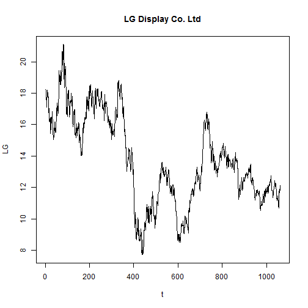

### Graph of stocks and returns

### LG Display Co. Ltd

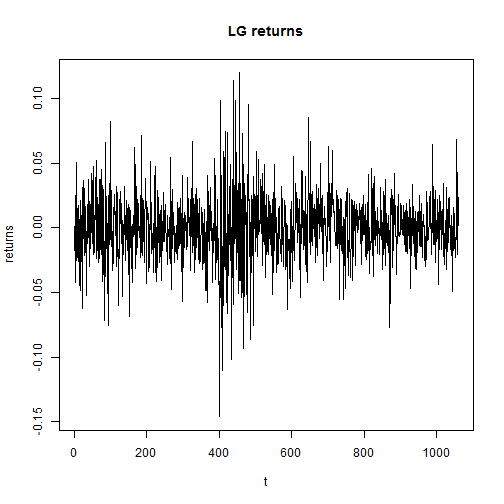

### Mean, Standard deviation(Volatility), Skewness, and Kurtosis

### LG Display Co. Ltd

```r
z <- scale(lg.return)
skew.lg <- mean(z^3) ; kurt.lg <- mean(z^4)
print(c(mean(lg.return),sd(lg.return),skew.lg,kurt.lg))
```

```
[1] -0.000383  0.026411 -0.001076  5.560847
```

### Daily returns follow Normal distribution??

### LG Display Co. Ltd

```r
hist(lg.return,prob=T,nclass=50)
x <- seq(from=-0.10,to=0.15,by=0.0001)
lines(x,dnorm(x,mean=mean(lg.return),sd(lg.return)),col=2)
```

### Daily returns follow Normal distribution??

### LG Display Co. Ltd

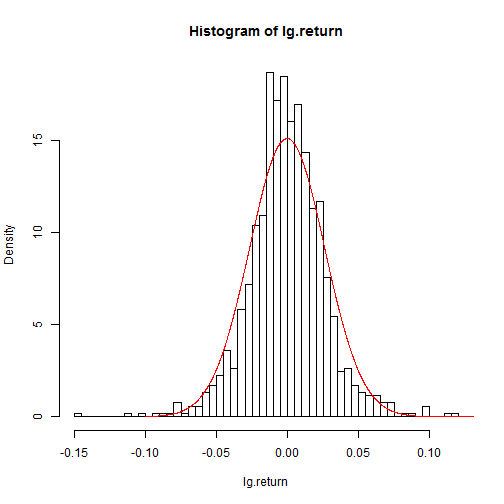

### Daily returns follow Normal distribution??

#### Interpretation

Refer to the histogram and graph, we can easily catch distribution of daily returns is not normal.

### Shapiro-Wilk normality test

```r
qqnorm(lg.return)
qqline(lg.return)
shapiro.test(lg.return)
```

### Shapiro-Wilk normality test

### LG Display Co. Ltd

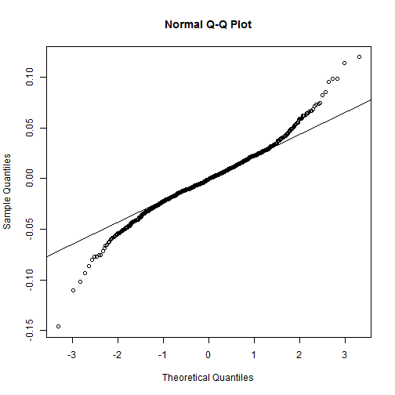

### Shapiro-Wilk normality test

### LG Display Co. Ltd

```
    Shapiro-Wilk normality test

data:  lg.return
W = 0.9735, p-value = 5.379e-13
```

### Autocorrelation function

```r
acf(lg.return)
acf(abs(lg.return))
```

### Autocorrelation function

### LG Display Co. Ltd

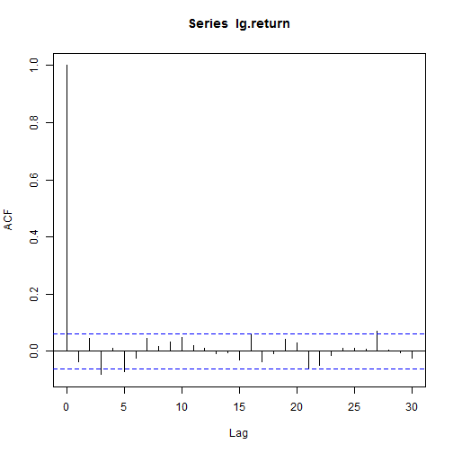

### Autocorrelation function

### LG Display Co. Ltd

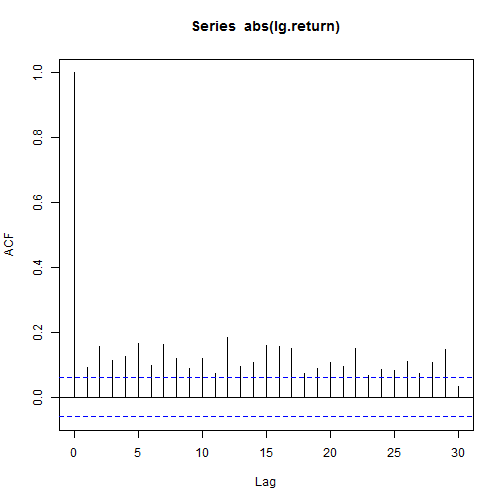

### Autocorrelation function

#### Interpretation

We have to analyze into variation of returns rather than returns itself refer to the two autocorrelation function.

### Genelarized Hyperbolic Distribution (Normal-Inverse Gaussian Distribution)

### Install package 'fBasics' and make function of calculate volatility in NIG assumption

```r
library(fBasics)
nig.volatility <- function(alpha,beta,delta,mu) {
  gamma <- sqrt(alpha^2-beta^2)
  ans <- sqrt(delta*alpha^2/gamma^3)
  return(ans)
}
```

### Parameter estimate in NIG assumption and histogram, graph

### LG Display Co., Ltd

```r
nigFit(lg.return)
hist(lg.return,prob=T,nclass=50)
x <- seq(from=-0.10,to=0.15,by=0.0001)
lines(x,dnorm(x,mean=mean(lg.return),sd(lg.return)),col=2)
lines(x,dnig(x,41.6633981699,0.8777504231,
             0.0288644214,-0.0009912696),col=3)
```

### Parameter estimate in NIG assumption and histogram, graph

### LG Display Co., Ltd

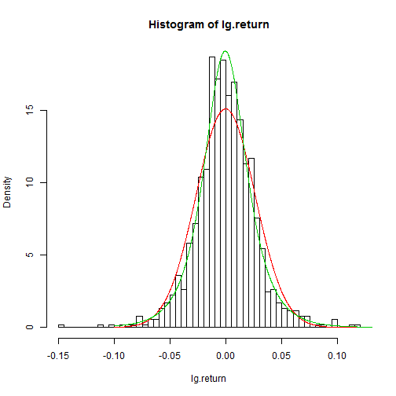

### Parameter estimate in NIG assumption and histogram, graph

#### Interpretation

Refer to the histogram and graph, when NIG assumption, it is well fit daily returns compared to the Normal assumption.

### Volatility at Risk

### LG Display Co., Ltd

```r
nig.volatility <- function(alpha,beta,delta,mu) {
  gamma <- sqrt(alpha^2-beta^2)
  ans <- sqrt(delta*alpha^2/gamma^3)
  return(ans)
}
vol.lg <- nig.volatility(41.6633981699,0.8777504231,0.0288644214,-0.0009912696)
std.lg <- sd(lg.return)
print(c(vol.lg,std.lg))
```

```
[1] 0.02633 0.02641
```

### Volatility at Risk

#### Interpretation

When use Normal Inverse Gaussian Distribution, estimate of volatility is almost similar to the real volatility.

### Value-at Risk

### LG Display Co., Ltd

```r
a1 <- qnig(0.05,41.6633981699,0.8777504231,0.0288644214,-0.0009912696) # 95% VaR
a2 <- qnorm(0.05,mean(lg.return),sd(lg.return)) # 95% VaR
print(c(a1,a2))
```

```
[1] -0.04222 -0.04382
```

### Value-at Risk

### LG Display Co., Ltd

```r
a3 <- qnig(0.005,41.6633981699,0.8777504231,0.0288644214,-0.0009912696) # 99.5% VaR
a4 <- qnorm(0.005,mean(lg.return),sd(lg.return)) # 99.5% VaR
print(c(a3,a4))
```

```
[1] -0.08205 -0.06841
```

### Value-at Risk

### LG Display Co., Ltd

```r
a5 <- qnig(0.01,41.6633981699,0.8777504231,0.0288644214,-0.0009912696) # 99% VaR
a6 <- qnorm(0.01,mean(lg.return),sd(lg.return)) # 99% VaR
print(c(a5,a6))
```

```
[1] -0.06971 -0.06182
```

### Value-at Risk

#### Interpretation

Refer to the Value-at-Risk, Normal distribution is underestimated risk of returns. So we have to analyze daily returns carefully. When we analyze daily returns, NIG assumptions is better than Normal assumptions.

### Conditional Heteroscedastic Model

Suppose that S(t) is asset price.

r(t) = log(S(t))-log(S(t-1)) : log-return or return

r(t) = sigma(t)*e(t) , e(t) ~ WN(0,1) (e : epsilon)

sigma(t)<sup>2</sup> = Var(r(t) | r(t-1), r(t-2), …)

= E(r(t)<sup>2</sup> | r(t-1), r(t-2), …)

Parameter estimate in GARCH(1,1) model and checking residuals. -> Plot ACF. -> Box-Ljung test (H0 : Not correlation.)

### Generalized Autoregressive Conditional Heteroscedastic Model (GARCH Model)

GARCH(1,1) –>

sigma(t)<sup>2</sup> = alpha(0) + alpha(1)*r(t-1)<sup>2</sup> +

beta(1)*sigma(t-1)<sup>2</sup> (t=1,2,…,T)

We have to check Goodness-of fit of GARCH(1,1) model.

### Install package 'tseries'

```r
library(tseries)
```

### Fitted GARCH(1,1) model to volatility of data

```r
vol.lg <- garch(lg.return)
```

### Returns, Estimated volatility and Residuals

### LG Display Co. Ltd

```r
vol.lg <- garch(lg.return)
plot(lg.return,type="l",main="LG returns",xlab="t",ylab="returns")
plot(vol.lg$fitted.values[,1],type="l",main="Estimated volatility")
plot(vol.lg$residuals,type="l",main="Residuals")
```

### Returns, Estimated volatility and Residuals

### LG Display Co. Ltd

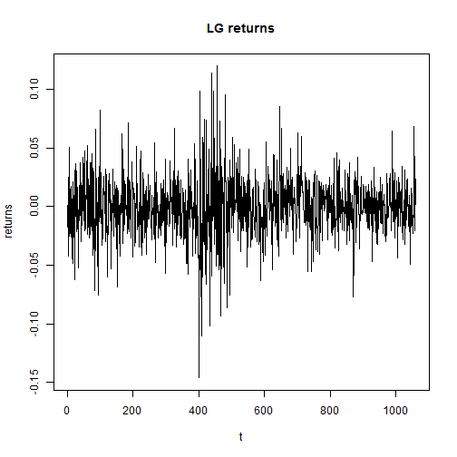

### Returns, Estimated volatility and Residuals

### LG Display Co. Ltd

[output not shown]

### Returns, Estimated volatility and Residuals

### LG Display Co. Ltd

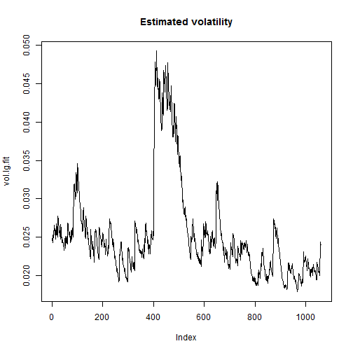

### Returns, Estimated volatility and Residuals

### LG Display Co. Ltd

[output not shown]

### Returns, Estimated volatility and Residuals

### LG Display Co. Ltd

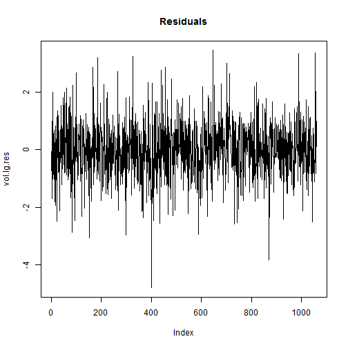

### Returns, Estimated volatility and Residuals

#### Interpretation

We can check variation of volatility when time goes. So we have to use GARCH model to modeling this.

### Checking fitted GARCH model

### LG Display Co. Ltd

```r
vol.lg <- garch(lg.return)
summary(vol.lg)
```

### Checking fitted GARCH model

### LG Display Co. Ltd

[output not shown]

```
Call:
garch(x = lg.return)

Model:
GARCH(1,1)

Residuals:
    Min      1Q  Median      3Q     Max
-4.8080 -0.6238 -0.0305  0.5886  3.4635

Coefficient(s):
    Estimate  Std. Error  t value Pr(>|t|)
a0  1.13e-05    4.36e-06     2.59   0.0095 **
a1  4.38e-02    7.89e-03     5.56  2.7e-08 ***
b1  9.39e-01    1.27e-02    73.79  < 2e-16 ***
---
Signif. codes:  0 '***' 0.001 '**' 0.01 '*' 0.05 '.' 0.1 ' ' 1

Diagnostic Tests:
    Jarque Bera Test

data:  Residuals
X-squared = 59.26, df = 2, p-value = 1.357e-13


    Box-Ljung test

data:  Squared.Residuals
X-squared = 0.1935, df = 1, p-value = 0.66
```

### Checking fitted GARCH model

#### Interpretation

Refer to approximation t-test, we can say estimated parameters are not equal to 0. And in Jarque Bera test, p-value is less than 0.05. That means residuals are not normality. Also in Box-Ljung test, p-value is greater than 0.05. So, GARCH(1,1) is well fitted volatility.

### Autocorrelation check for residuals

```r
acf(lg.return)
acf(lg.return^2)
acf(vol.lg$residuals[-1])
acf(vol.lg$residuals[-1]^2)
```

### Autocorrelation check for residuals

### LG Display Co. Ltd

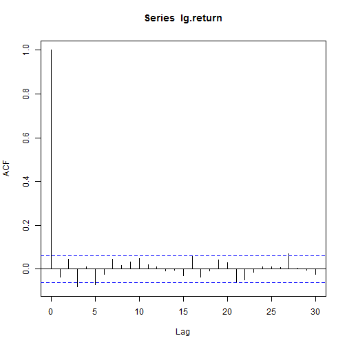

### Autocorrelation check for residuals

### LG Display Co. Ltd

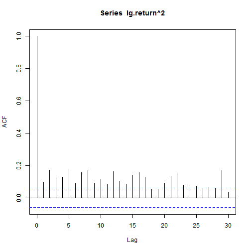

### Autocorrelation check for residuals

### LG Display Co. Ltd

[output not shown]

### Autocorrelation check for residuals

### LG Display Co. Ltd

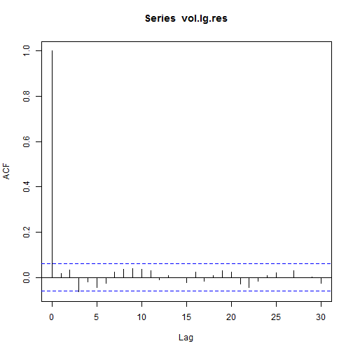

### Autocorrelation check for residuals

### LG Display Co. Ltd

[output not shown]

### Autocorrelation check for residuals

### LG Display Co. Ltd

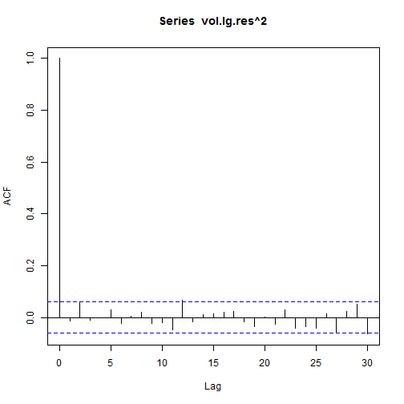

### Autocorrelation check for residuals

#### Interpretation

Refer to the autocorrelation function of residuals, almost residuals are in the confidence interval. So we can say residuals have not autocorrelation. That means GARCH(1,1) model is well fitted volatility.

### Modeling daily returns

If r ~ N( 0 , sigma<sup>2</sup> ) , it is not true..

r(t) = sigma(t)*e(t) , e(t) ~ WN(0,1) (e : epsilon)

e(t) is called random shocks..

GARCH(1,1) -> sigma(t)<sup>2</sup> = alpha(0) + alpha(1)*r(t-1)<sup>2</sup>

- beta(1)*sigma(t-1)<sup>2</sup>

Refer to Jarque Bera Test, e(t) is nonnormal~~!!

### Checking distribution of epsilon

### LG Display Co. Ltd

```r
vol.lg <- garch(lg.return)
res.lg <- vol.lg$residuals[-1]
nigFit(res.lg)
hist(res.lg,prob=T,nclass=50)
x <- seq(-4,2,by=0.001)
lines(x,dnorm(x),col=2)
lines(x,dnig(x,1.52580370,-0.01264153,1.53086941,-0.00903504),col=3)
```

### Checking distribution of epsilon

### LG Display Co. Ltd

[output not shown]

### Checking distribution of epsilon

### LG Display Co. Ltd

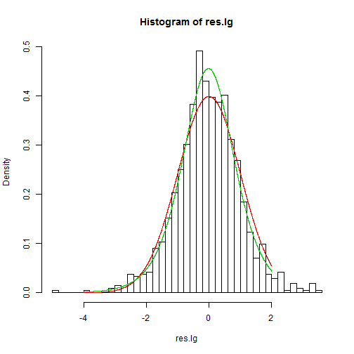

### Checking distribution of epsilon

#### Interpretation

Refer to the histogram and graph, when use NIG assumption, residuals from the GARCH(1,1) are well fitted.

### Time varying Value-at Risk

P(r(t) <= x ) = 0.01 (Value-at-Risk)

P(sigma(t)*e(t) <=

sigma(t)*y ) = 0.01 (Find y!!)

We have to find y. And product estimated sigma(t) from the GARCH(1,1) model. Let's calculate this and plot it.

### Time varying Value-at Risk

### LG Display Co. Ltd

```r
q.05 <- qnig(0.05,1.52580370,-0.01264153,1.53086941,-0.00903504)
q.01 <- qnig(0.01,1.52580370,-0.01264153,1.53086941,-0.00903504)
q.005 <- qnig(0.005,1.52580370,-0.01264153,1.53086941,-0.00903504)
sigma.t <- garch(lg.return)$fitted.values[-1,1]
VaR.95 <- sigma.t*q.05
VaR.99 <- sigma.t*q.01
VaR.995 <- sigma.t*q.005
n <- length(lg.return)
plot(lg.return,type="l",ylim=c(-0.15,0.15))
lines(2:n,VaR.95,col=2)
lines(2:n,VaR.99,col=3)
lines(2:n,VaR.995,col=4)
legend("topleft",c("95% VaR","99% VaR","99.5% VaR"),lty=rep(1,3),col=c(2,3,4))
```

### Time varying Value-at Risk

### LG Display Co. Ltd

[output not shown]

### Time varying Value-at Risk

### LG Display Co. Ltd

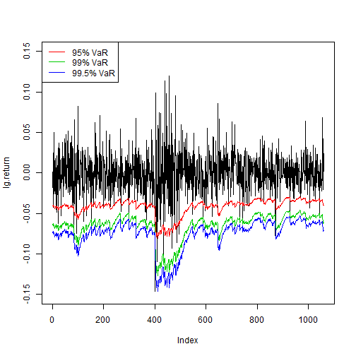

### Checking accuracy

### LG Display Co. Ltd

```r
vol.lg <- garch(lg.return)
q.05 <- qnig(0.05,1.52580370,-0.01264153,1.53086941,-0.00903504)
q.01 <- qnig(0.01,1.52580370,-0.01264153,1.53086941,-0.00903504)
q.005 <- qnig(0.005,1.52580370,-0.01264153,1.53086941,-0.00903504)
sigma.t <- vol.lg$fitted.values[-1,1]
VaR.N95 <- sigma.t*qnorm(0.05)
VaR.N99 <- sigma.t*qnorm(0.01)
VaR.N995 <- sigma.t*qnorm(0.005)
VaR.95 <- sigma.t*q.05
VaR.99 <- sigma.t*q.01
VaR.995 <- sigma.t*q.005
print(c(abs(0.05-mean(lg.return[-1] < VaR.N95)),abs(0.05-mean(lg.return[-1] < VaR.95))))
print(c(abs(0.01-mean(lg.return[-1] < VaR.N99)),abs(0.01-mean(lg.return[-1] < VaR.99))))
print(c(abs(0.005-mean(lg.return[-1] < VaR.N995)),abs(0.005-mean(lg.return[-1] < VaR.995))))
```

### Checking accuracy

### LG Display Co. Ltd

```r
q.05 <- qnig(0.05,1.52580370,-0.01264153,1.53086941,-0.00903504)
sigma.t <- vol.lg$fitted.values[-1,1]
VaR.N95 <- sigma.t*qnorm(0.05)
VaR.95 <- sigma.t*q.05
print(c(abs(0.05-mean(lg.return[-1] < VaR.N95)),abs(0.05-mean(lg.return[-1] < VaR.95))))
```

```
[1] 0.00288 0.00288
```

### Checking accuracy

### LG Display Co. Ltd

```r
q.01 <- qnig(0.01,1.52580370,-0.01264153,1.53086941,-0.00903504)
sigma.t <- vol.lg$fitted.values[-1,1]
VaR.N99 <- sigma.t*qnorm(0.01)
VaR.99 <- sigma.t*q.01
print(c(abs(0.01-mean(lg.return[-1] < VaR.N99)),abs(0.01-mean(lg.return[-1] < VaR.99))))
```

```
[1] 0.007941 0.002446
```

### Checking accuracy

### LG Display Co. Ltd

```r
q.005 <- qnig(0.005,1.52580370,-0.01264153,1.53086941,-0.00903504)
sigma.t <- vol.lg$fitted.values[-1,1]
VaR.N995 <- sigma.t*qnorm(0.005)
VaR.995 <- sigma.t*q.005
print(c(abs(0.005-mean(lg.return[-1] < VaR.N995)),abs(0.005-mean(lg.return[-1] < VaR.995))))
```

```
[1] 0.002554 0.001223
```

### Checking accuracy

#### Interpretation

According to the result, Normal Inverse Gaussian Distribution is better than Normal Distribution when checking Value-at-Risk of daily returns. In addition, Normal distribution is underestimated risk of daily returns.

### Backtest Value-at-Risk

Suppose that N is number of 100*(1-p)% VaR violations and T is the total number of observations.

H0 : N ~ B(T,p) vs H1 : not H0

LRT statistic = - 2*log{((1-p)<sup>T-N</sup>) *((p)<sup>N</sup>)} + 2*log{((1-N/T)<sup>T-N</sup> )*((N/T)<sup>N</sup>)}

–>d (Convergence in distribution) Chi-square distribution with df=1 under H0

(LRT statistic = -2*log(L0/L))

### Backtest Value-at-Risk

### Make function for backtest Value-at-Risk

```r
backtest.VaR <- function(N.violations, N.total, p) {
  p.hat <- N.violations/N.total
  LR <- -2*log((1-p)^(N.total-N.violations)*p^N.violations)+2*log((1-p.hat)^(N.total-N.violations)*p.hat^N.violations)
  p.value <- 1-pchisq(LR,1)
  return(list(excess.prob=p.hat, LR=LR, p.value=p.value))
}
```

### Backtest Value-at-Risk (NIG assumption)

### LG Display Co. Ltd

```r
q.05 <- qnig(0.05,1.52580370,-0.01264153,1.53086941,-0.00903504)
q.01 <- qnig(0.01,1.52580370,-0.01264153,1.53086941,-0.00903504)
q.005 <- qnig(0.005,1.52580370,-0.01264153,1.53086941,-0.00903504)
sigma.t <- garch(lg.return)$fitted.values[-1,1]
VaR.95 <- sigma.t*q.05
VaR.99 <- sigma.t*q.01
VaR.995 <- sigma.t*q.005
backtest.VaR(sum(lg.return[-1] < VaR.95),length(lg.return[-1]),0.05)
backtest.VaR(sum(lg.return[-1] < VaR.99),length(lg.return[-1]),0.01)
backtest.VaR(sum(lg.return[-1] < VaR.995),length(lg.return[-1]),0.005)
```

### Backtest Value-at-Risk (NIG assumption)

### LG Display Co. Ltd

```r
backtest.VaR <- function(N.violations, N.total, p) {
  p.hat <- N.violations/N.total
  LR <- -2*log((1-p)^(N.total-N.violations)*p^N.violations)+2*log((1-p.hat)^(N.total-N.violations)*p.hat^N.violations)
  p.value <- 1-pchisq(LR,1)
  return(list(excess.prob=p.hat, LR=LR, p.value=p.value))
}
backtest.VaR(sum(lg.return[-1] < VaR.95),length(lg.return[-1]),0.05)
```

### Backtest Value-at-Risk (NIG assumption)

### LG Display Co. Ltd

```
$excess.prob
[1] 0.05288

$LR
[1] 0.1817

$p.value
[1] 0.6699
```

### Backtest Value-at-Risk (NIG assumption)

### LG Display Co. Ltd

```r
backtest.VaR <- function(N.violations, N.total, p) {
  p.hat <- N.violations/N.total
  LR <- -2*log((1-p)^(N.total-N.violations)*p^N.violations)+2*log((1-p.hat)^(N.total-N.violations)*p.hat^N.violations)
  p.value <- 1-pchisq(LR,1)
  return(list(excess.prob=p.hat, LR=LR, p.value=p.value))
}
backtest.VaR(sum(lg.return[-1] < VaR.99),length(lg.return[-1]),0.01)
```

### Backtest Value-at-Risk (NIG assumption)

### LG Display Co. Ltd

```
$excess.prob
[1] 0.007554

$LR
[1] 0.6989

$p.value
[1] 0.4032
```

### Backtest Value-at-Risk (NIG assumption)

### LG Display Co. Ltd

```r
backtest.VaR <- function(N.violations, N.total, p) {
  p.hat <- N.violations/N.total
  LR <- -2*log((1-p)^(N.total-N.violations)*p^N.violations)+2*log((1-p.hat)^(N.total-N.violations)*p.hat^N.violations)
  p.value <- 1-pchisq(LR,1)
  return(list(excess.prob=p.hat, LR=LR, p.value=p.value))
}
backtest.VaR(sum(lg.return[-1] < VaR.995),length(lg.return[-1]),0.005)
```

### Backtest Value-at-Risk (NIG assumption)

### LG Display Co. Ltd

```
$excess.prob
[1] 0.003777

$LR
[1] 0.3478

$p.value
[1] 0.5553
```

### Backtest Value-at-Risk (NIG assumption)

#### Interpretation

Refer to the backtest in NIG assumption, p-value is greater than 0.05. So we can conclude Normal Inverse Gaussian Distribution is well fitted daily returns.

### Backtest Value-at-Risk (Normality assumption)

### LG Display Co. Ltd

```r
sigma.t <- garch(lg.return)$fitted.values[-1,1]
VaR.N95 <- sigma.t*qnorm(0.05)
VaR.N99 <- sigma.t*qnorm(0.01)
VaR.N995 <- sigma.t*qnorm(0.005)
backtest.VaR(sum(lg.return[-1] < VaR.N95),length(lg.return[-1]),0.05)
backtest.VaR(sum(lg.return[-1] < VaR.N99),length(lg.return[-1]),0.01)
backtest.VaR(sum(lg.return[-1] < VaR.N995),length(lg.return[-1]),0.005)
```

### Backtest Value-at-Risk (Normality assumption)

### LG Display Co. Ltd

```r
backtest.VaR <- function(N.violations, N.total, p) {
  p.hat <- N.violations/N.total
  LR <- -2*log((1-p)^(N.total-N.violations)*p^N.violations)+2*log((1-p.hat)^(N.total-N.violations)*p.hat^N.violations)
  p.value <- 1-pchisq(LR,1)
  return(list(excess.prob=p.hat, LR=LR, p.value=p.value))
}
backtest.VaR(sum(lg.return[-1] < VaR.N95),length(lg.return[-1]),0.05)
```

### Backtest Value-at-Risk (Normality assumption)

### LG Display Co. Ltd

```
$excess.prob
[1] 0.05288

$LR
[1] 0.1817

$p.value
[1] 0.6699
```

### Backtest Value-at-Risk (Normality assumption)

### LG Display Co. Ltd

```r
backtest.VaR <- function(N.violations, N.total, p) {
  p.hat <- N.violations/N.total
  LR <- -2*log((1-p)^(N.total-N.violations)*p^N.violations)+2*log((1-p.hat)^(N.total-N.violations)*p.hat^N.violations)
  p.value <- 1-pchisq(LR,1)
  return(list(excess.prob=p.hat, LR=LR, p.value=p.value))
}
backtest.VaR(sum(lg.return[-1] < VaR.N99),length(lg.return[-1]),0.01)
```

### Backtest Value-at-Risk (Normality assumption)

### LG Display Co. Ltd

```
$excess.prob
[1] 0.01794

$LR
[1] 5.46

$p.value
[1] 0.01946
```

### Backtest Value-at-Risk (Normality assumption)

### LG Display Co. Ltd

```r
backtest.VaR <- function(N.violations, N.total, p) {
  p.hat <- N.violations/N.total
  LR <- -2*log((1-p)^(N.total-N.violations)*p^N.violations)+2*log((1-p.hat)^(N.total-N.violations)*p.hat^N.violations)
  p.value <- 1-pchisq(LR,1)
  return(list(excess.prob=p.hat, LR=LR, p.value=p.value))
}
backtest.VaR(sum(lg.return[-1] < VaR.N995),length(lg.return[-1]),0.005)
```

### Backtest Value-at-Risk (Normality assumption)

### LG Display Co. Ltd

```
$excess.prob
[1] 0.007554

$LR
[1] 1.2

$p.value
[1] 0.2734
```

### Backtest Value-at-Risk (Normality assumption)

#### Interpretation

Refer to the backtest result, in general, p-value is not always greater than 0.05. So it is wrong method to use Normal Distribution when analyze daily returns. Be careful!!